# Project: Investigate a Dataset (IMDB Database)

- Introduction
- Data Wrangling
- Exploratory Data Analysis
- Conclusions

## Introduction

```python
# importing lib
import pandas as pd
import numpy as np
import matplotlib.pyplot as plt
%matplotlib inline

#read CSV
df = pd.read_csv('tmdb-movies.csv')

#Check it
df.shape
```

```
(10866, 21)
```

## Data Wrangling

> **Is the related data clean?**: I'll check for nulls and duplicated values in related data only:

### General Properties

```python
# info
df.info()
```

```
<class 'pandas.core.frame.DataFrame'>
RangeIndex: 10866 entries, 0 to 10865
Data columns (total 21 columns):
id                      10866 non-null int64
imdb_id                 10856 non-null object
popularity              10866 non-null float64
budget                  10866 non-null int64
revenue                 10866 non-null int64
original_title          10866 non-null object
cast                    10790 non-null object
homepage                2936 non-null object
director                10822 non-null object
tagline                 8042 non-null object
keywords                9373 non-null object
overview                10862 non-null object
runtime                 10866 non-null int64
genres                  10843 non-null object
production_companies    9836 non-null object
release_date            10866 non-null object
vote_count              10866 non-null int64
vote_average            10866 non-null float64
release_year            10866 non-null int64
budget_adj              10866 non-null float64
revenue_adj             10866 non-null float64
dtypes: float64(4), int64(6), object(11)
memory usage: 1.7+ MB
```

```python
df.shape
```

```
(10866, 21)
```

```python
sum(df.duplicated())
```

```
1
```

### Data Cleaning (Drop unnecessary data!)

```python
#Drop nnecessary data columns
df.drop(columns=['homepage','tagline','keywords','cast','keywords','overview','runtime','production_companies'],axis=1,inplace=True)
df.shape
```

```
(10866, 14)
```

```python
# find duplicated entries after removing columns.
sum(df.duplicated())
```

```
1
```

```python
#Remove duplicated entries
df.drop_duplicates(inplace=True)
```

```python
#Check for removal
df.shape
```

```
(10865, 14)
```

```python
#Remove any entries without director name
df.director.dropna(inplace=True)
```

```python
#Recheck
df.shape
```

```
(10865, 14)
```

## Exploratory Data Analysis.

### What's the relation between movies and it's directors?

```python
#Directors who have directed most movies:
df['director'].value_counts().head()
```

```
Woody Allen         45
Clint Eastwood      34
Martin Scorsese     29
Steven Spielberg    29
Ridley Scott        23
Name: director, dtype: int64
```

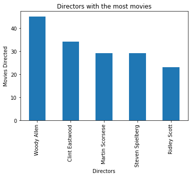

```python
df['director'].value_counts().head().plot(kind='bar')
plt.title("Directors with the most movies")
plt.xlabel("Directors")
plt.ylabel("Movies Directed")
```

```python
#Top Rated Directors:
top_dir = df['director'].groupby(df.vote_average).unique().tail()
top_dir
```

```
vote_average
8.5    [Curt Morgan, James Payne, Martin Scorsese|Mic...
8.7                                       [David Mallet]
8.8                    [Carl Tibbetts, Derek Frankowski]
8.9                             [Jennifer Siebel Newsom]
9.2                                       [Mark Cousins]
Name: director, dtype: object
```

### How does movie production improved in the last ten years?

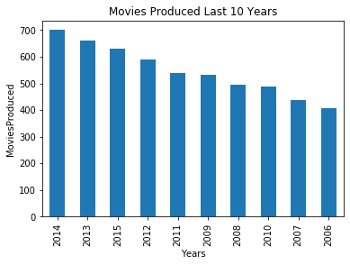

```python
# How many movies produced per year in the last 10 years:

df['release_year'].value_counts().head(10).plot(kind='bar')
plt.title("Movies Produced Last 10 Years")
plt.xlabel("Years")
plt.ylabel("MoviesProduced")
```

## Conclusions

> **Summary**:
> 1. The most movies were directed by \"Woody Allen\" with a high score of 45 movies but, unfortunately, none of them was the best-rated, The best-rated movies belong to Mark Cousins with the high score of 9.2 out of 10.
> 2. Movie production is improving over the years as we can see the number of movies making progress over years although it sometimes drops but, it still improves.